# 02-Single-Cell RNA-Seq Analysis: DEA & PEA

Author

Dr Badran Elshenawy

Published

January 1, 2026

# Introduction

- this module covers differential expression analysis (DEA) and pathway enrichment analysis (PEA)
- we continue from the processed Seurat object created in the QC & Pre-processing module
- DEA identifies genes differentially expressed between clusters or conditions
- PEA reveals biological pathways and processes enriched in our gene lists
- we’ll use both ORA (over-representation analysis) and GSEA (gene set enrichment analysis)
- for simplicity, we focus on a single cluster (cluster 0) throughout this tutorial

# Package Installation

- `clusterProfiler` is the gold standard for pathway enrichment analysis in R
- `org.Hs.eg.db` provides human gene annotations for mapping gene symbols to Entrez IDs
- `enrichplot` provides visualization functions for enrichment results
- `DOSE` provides disease ontology analysis capabilities
- `BadranSeq` provides publication-ready visualizations for single-cell data
- `conflicted` helps manage function name conflicts between packages

```r
# install BiocManager if not already installed
if (!requireNamespace("BiocManager", quietly = TRUE)) {
  install.packages("BiocManager")
}

# install CRAN packages
install.packages(c(
  "tidyverse",
  "Seurat",
  "devtools",
  "conflicted"
))

# install BadranSeq for publication-ready visualizations
devtools::install_github("wolf5996/BadranSeq")

# install Bioconductor packages for pathway analysis
BiocManager::install(c(
  "clusterProfiler",
  "org.Hs.eg.db",
  "enrichplot",
  "DOSE"
))
```

# Directory Structure

- organizing project files into clear subdirectories makes analyses reproducible and shareable
- `read/` stores input data files (raw counts, annotations, metadata)
- `write/` stores output files, further organized into `figures/` and `tables/`
- `scripts/` contains analysis code (this file lives here)
- `checkpoints/` stores intermediate Seurat objects for long-running analyses

```r
# create directory structure (safe to run even if directories exist)
dir.create(
  "../read",
  showWarnings = FALSE
)
dir.create(
  "../write",
  showWarnings = FALSE
)
dir.create(
  "../write/figures",
  showWarnings = FALSE
)
dir.create(
  "../write/tables",
  showWarnings = FALSE
)
dir.create(
  "../checkpoints",
  showWarnings = FALSE
)
```

# Conflict Handling

- R packages sometimes have functions with the same name (e.g., `filter` in dplyr and stats)
- the `conflicted` package makes these conflicts explicit and forces you to choose
- `conflicts_prefer()` sets which package’s version to use by default
- this prevents silent errors from using the wrong function

```r
# packages
library(conflicted)

# resolve common conflicts
conflicts_prefer(dplyr::filter)
conflicts_prefer(dplyr::select)
conflicts_prefer(dplyr::rename)
conflicts_prefer(base::setdiff)
```

# 1. Differential Expression Analysis (DEA)

- DEA identifies genes with significant expression differences between groups
- Seurat’s `FindAllMarkers()` compares each cluster against all others
- we use the Wilcoxon rank-sum test (default) for statistical testing
- `min.pct` filters genes expressed in fewer than 20% of cells
- `logfc.threshold` filters genes with small fold changes

## 1.1 Find Cluster Markers

- identify marker genes for each cluster
- these genes distinguish each cluster from all other cells

```r
# packages
library(tidyverse)
library(Seurat)
library(magrittr)

# load data
ifnb_filtered <- read_rds("../checkpoints/ifnb_processed.rds")

# verify cluster identities are set correctly
all(Idents(ifnb_filtered) == ifnb_filtered$seurat_clusters)
```

```
[1] TRUE
```

```r
# find markers for all clusters
cluster_markers <- FindAllMarkers(
  object = ifnb_filtered,
  min.pct = 0.2,
  logfc.threshold = 0.2,
  verbose = FALSE
)

# preview results
cluster_markers %>%
  head(20)
```

```
         p_val avg_log2FC pct.1 pct.2 p_val_adj cluster     gene
IL8          0   4.519391 0.896 0.102         0       0      IL8
S100A8       0   4.501904 0.838 0.106         0       0   S100A8
CD14         0   3.876090 0.764 0.084         0       0     CD14
C15orf48     0   1.706855 0.979 0.320         0       0 C15orf48
MARCKSL1     0   2.752469 0.872 0.219         0       0 MARCKSL1
PLAUR        0   2.826370 0.836 0.190         0       0    PLAUR
FCER1G       0   1.680413 0.990 0.352         0       0   FCER1G
TYROBP       0   1.495316 0.997 0.363         0       0   TYROBP
S100A9       0   3.441997 0.768 0.140         0       0   S100A9
GPX1         0   2.541975 0.881 0.255         0       0     GPX1
ISG20        0  -4.393729 0.171 0.791         0       0    ISG20
S100A4       0   2.491782 0.937 0.326         0       0   S100A4
LGALS3       0   2.140669 0.949 0.338         0       0   LGALS3
LGALS1       0   1.946473 0.975 0.369         0       0   LGALS1
TIMP1        0   2.186707 0.999 0.412         0       0    TIMP1
CD63         0   2.056094 0.994 0.424         0       0     CD63
CTSB         0   1.569394 0.850 0.285         0       0     CTSB
ANXA5        0   1.847087 0.982 0.421         0       0    ANXA5
IFIT3        0  -5.775539 0.041 0.599         0       0    IFIT3
PSAP         0   1.902583 0.948 0.392         0       0     PSAP
```

```r
# save results
write_csv(
  x = cluster_markers,
  file = "../write/tables/ifnb_cluster_markers.csv"
)
```

## 1.2 Top Markers Per Cluster

- extract top markers for each cluster by log2 fold change
- these are the most distinctive genes for each cluster

```r
# packages
library(tidyverse)
library(magrittr)

# load data
cluster_markers <- read_csv(
  "../write/tables/ifnb_cluster_markers.csv",
  show_col_types = FALSE
)

# get top 10 markers per cluster
top_markers <- cluster_markers %>%
  group_by(cluster) %>%
  top_n(
    n = 10,
    wt = avg_log2FC
  ) %>%
  arrange(
    cluster,
    desc(avg_log2FC)
  )

# display top markers
top_markers %>%
  select(
    cluster,
    gene,
    avg_log2FC,
    p_val_adj
  )
```

```
# A tibble: 190 × 4
# Groups:   cluster [19]
   cluster gene       avg_log2FC p_val_adj
     <dbl> <chr>           <dbl>     <dbl>
 1       0 C19orf59         5.97         0
 2       0 CLEC5A           5.54         0
 3       0 VCAN             5.35         0
 4       0 CYP27A1          4.94         0
 5       0 IL1B             4.68         0
 6       0 OSM              4.64         0
 7       0 CTB-61M7.2       4.53         0
 8       0 IL8              4.52         0
 9       0 S100A8           4.50         0
10       0 IER3             4.07         0
# ℹ 180 more rows
```

```r
# save results
write_csv(
  x = top_markers,
  file = "../write/tables/ifnb_top_markers.csv"
)
```

## 1.3 Visualize Markers

- heatmap shows expression patterns of top markers across clusters
- helps validate that markers are cluster-specific

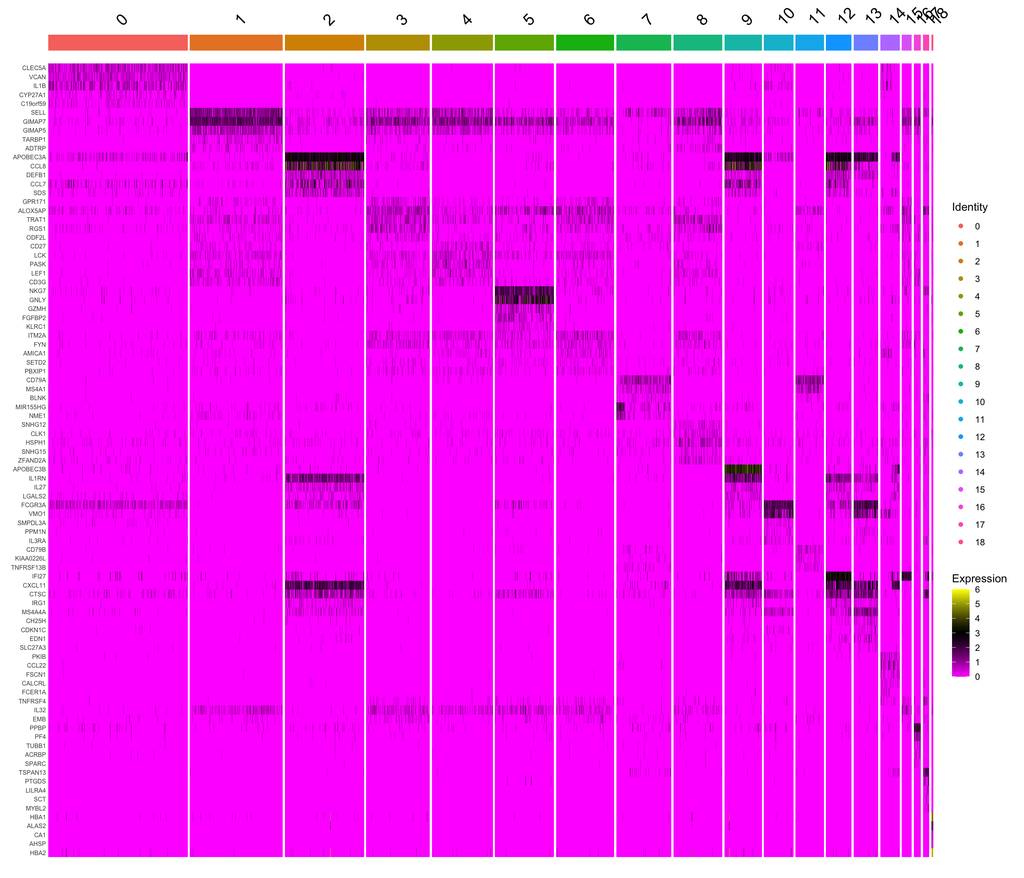

```r
# packages
library(tidyverse)
library(Seurat)
library(magrittr)

# load data
ifnb_filtered <- read_rds("../checkpoints/ifnb_processed.rds")
cluster_markers <- read_csv(
  "../write/tables/ifnb_cluster_markers.csv",
  show_col_types = FALSE
)

# get top 5 markers per cluster for heatmap
heatmap_genes <- cluster_markers %>%
  group_by(cluster) %>%
  top_n(
    n = 5,
    wt = avg_log2FC
  ) %>%
  pull(gene) %>%
  unique()

# create heatmap
DoHeatmap(
  object = ifnb_filtered,
  features = heatmap_genes,
  group.by = "seurat_clusters",
  slot = "data"
) +
  theme(
    axis.text.y = element_text(size = 6)
  )
```

```r
# save figure
ggsave(
  "../write/figures/dea_heatmap.png",
  width = 14,
  height = 12
)
```

# 2. Pathway Enrichment Analysis (PEA)

- PEA identifies biological pathways and processes enriched in gene lists
- two main approaches: ORA and GSEA
- ORA tests if pathway genes are over-represented in a gene list
- GSEA tests if pathway genes are enriched at the top/bottom of a ranked list
- we’ll perform both GO (Gene Ontology) and KEGG pathway analyses
- we focus on cluster 0 as an example - you can change the cluster number to analyze others

# 3. Over-Representation Analysis (ORA)

- ORA uses a hypergeometric test to find enriched pathways
- input: list of significant genes (e.g., upregulated markers)
- tests whether pathway genes appear more often than expected by chance

## 3.1 Extract Cluster 0 Markers

- filter marker genes for cluster 0 only
- focus on upregulated genes (positive log2FC)

```r
# packages
library(tidyverse)
library(magrittr)

# load data
cluster_markers <- read_csv(
  "../write/tables/ifnb_cluster_markers.csv",
  show_col_types = FALSE
)

# filter for cluster 0 upregulated genes
cluster0_markers <- cluster_markers %>%
  filter(
    cluster == 0,
    avg_log2FC > 0
  )

# preview
cluster0_markers %>%
  head(20)
```

```
# A tibble: 20 × 7
   p_val avg_log2FC pct.1 pct.2 p_val_adj cluster gene
   <dbl>      <dbl> <dbl> <dbl>     <dbl>   <dbl> <chr>
 1     0       4.52 0.896 0.102         0       0 IL8
 2     0       4.50 0.838 0.106         0       0 S100A8
 3     0       3.88 0.764 0.084         0       0 CD14
 4     0       1.71 0.979 0.32          0       0 C15orf48
 5     0       2.75 0.872 0.219         0       0 MARCKSL1
 6     0       2.83 0.836 0.19          0       0 PLAUR
 7     0       1.68 0.99  0.352         0       0 FCER1G
 8     0       1.50 0.997 0.363         0       0 TYROBP
 9     0       3.44 0.768 0.14          0       0 S100A9
10     0       2.54 0.881 0.255         0       0 GPX1
11     0       2.49 0.937 0.326         0       0 S100A4
12     0       2.14 0.949 0.338         0       0 LGALS3
13     0       1.95 0.975 0.369         0       0 LGALS1
14     0       2.19 0.999 0.412         0       0 TIMP1
15     0       2.06 0.994 0.424         0       0 CD63
16     0       1.57 0.85  0.285         0       0 CTSB
17     0       1.85 0.982 0.421         0       0 ANXA5
18     0       1.90 0.948 0.392         0       0 PSAP
19     0       5.54 0.567 0.016         0       0 CLEC5A
20     0       2.10 0.928 0.381         0       0 ATP6V0B
```

```r
# extract gene list for ORA
cluster0_genes <- cluster0_markers %>%
  pull(gene)

# show number of genes
paste(
  "Number of upregulated genes in cluster 0:",
  length(cluster0_genes)
)
```

```
[1] "Number of upregulated genes in cluster 0: 592"
```

```r
# save cluster 0 markers
write_csv(
  x = cluster0_markers,
  file = "../write/tables/cluster0_markers.csv"
)
```

## 3.2 GO ORA (Biological Process)

- Gene Ontology describes gene functions in three domains: BP, MF, CC
- BP (Biological Process) describes cellular processes genes are involved in
- we test if cluster 0 marker genes are enriched in specific biological processes

```r
# packages
library(tidyverse)
library(clusterProfiler)
library(org.Hs.eg.db)
library(enrichplot)
library(magrittr)

# load data
cluster0_markers <- read_csv(
  "../write/tables/cluster0_markers.csv",
  show_col_types = FALSE
)

# extract gene list
cluster0_genes <- cluster0_markers %>%
  pull(gene)

# perform GO enrichment for biological process
go_ora_result <- enrichGO(
  gene = cluster0_genes,
  OrgDb = org.Hs.eg.db,
  keyType = "SYMBOL",
  ont = "BP",
  pAdjustMethod = "BH",
  pvalueCutoff = 0.05,
  qvalueCutoff = 0.05,
  readable = TRUE
)

# preview results
go_ora_result@result %>%
  head(10) %>%
  select(
    Description,
    GeneRatio,
    pvalue,
    p.adjust
  )
```

```
                                                      Description GeneRatio
GO:0007015                            actin filament organization    45/541
GO:0030100                              regulation of endocytosis    35/541
GO:0006119                              oxidative phosphorylation    24/541
GO:0006091         generation of precursor metabolites and energy    44/541
GO:0019882                    antigen processing and presentation    21/541
GO:1902600                         proton transmembrane transport    26/541
GO:0042773               ATP synthesis coupled electron transport    19/541
GO:0042775 mitochondrial ATP synthesis coupled electron transport    19/541
GO:0050900                                    leukocyte migration    38/541
GO:0045333                                   cellular respiration    29/541
                 pvalue     p.adjust
GO:0007015 9.456983e-13 4.305764e-09
GO:0030100 4.791506e-12 1.090786e-08
GO:0006119 9.603240e-12 1.457452e-08
GO:0006091 1.627293e-11 1.617706e-08
GO:0019882 1.776528e-11 1.617706e-08
GO:1902600 4.267316e-11 3.238181e-08
GO:0042773 6.998746e-11 3.983161e-08
GO:0042775 6.998746e-11 3.983161e-08
GO:0050900 8.042465e-11 4.068593e-08
GO:0045333 1.163442e-10 5.297151e-08
```

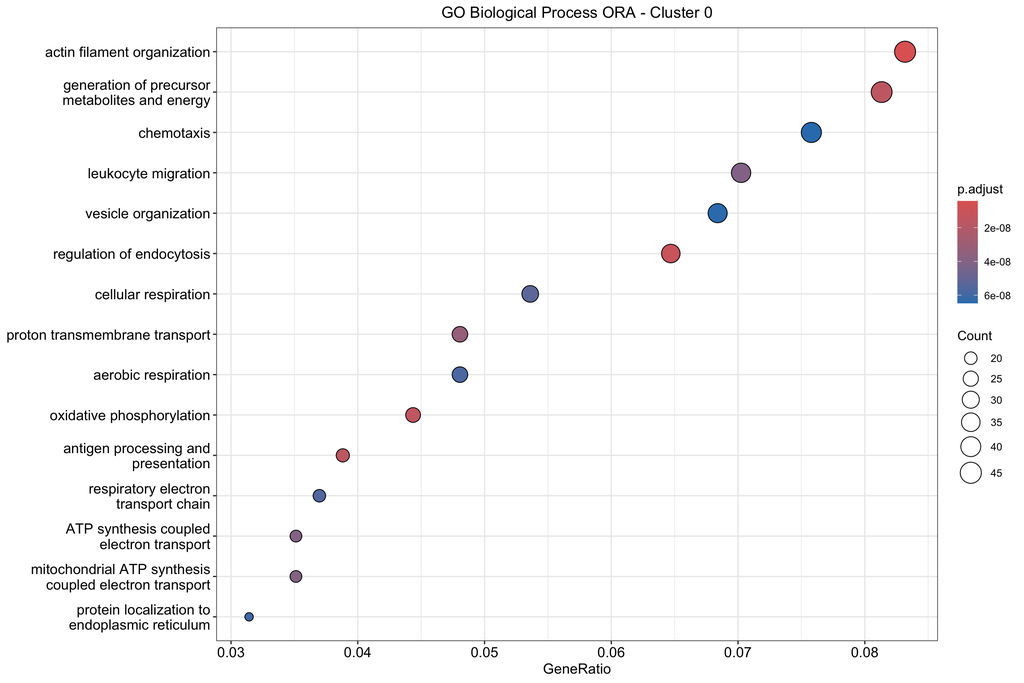

```r
# visualize with dotplot
dotplot(
  go_ora_result,
  showCategory = 15
) +
  ggtitle("GO Biological Process ORA - Cluster 0") +
  theme(
    plot.title = element_text(hjust = 0.5)
  )
```

```r
# save figure
ggsave(
  "../write/figures/go_ora_cluster0.png",
  width = 12,
  height = 8
)

# save results table
write_csv(
  x = go_ora_result@result,
  file = "../write/tables/go_ora_cluster0.csv"
)

# save full results object
write_rds(
  go_ora_result,
  "../checkpoints/go_ora_cluster0.rds"
)
```

## 3.3 KEGG ORA

- KEGG (Kyoto Encyclopedia of Genes and Genomes) contains curated pathway maps
- requires Entrez IDs rather than gene symbols
- we first convert gene symbols to Entrez IDs

```r
# packages
library(tidyverse)
library(clusterProfiler)
library(org.Hs.eg.db)
library(enrichplot)
library(magrittr)

# load data
cluster0_markers <- read_csv(
  "../write/tables/cluster0_markers.csv",
  show_col_types = FALSE
)

# extract gene list
cluster0_genes <- cluster0_markers %>%
  pull(gene)

# convert gene symbols to Entrez IDs
gene_entrez <- bitr(
  cluster0_genes,
  fromType = "SYMBOL",
  toType = "ENTREZID",
  OrgDb = org.Hs.eg.db
)

# show conversion results
paste(
  "Converted",
  nrow(gene_entrez),
  "of",
  length(cluster0_genes),
  "genes to Entrez IDs"
)
```

```
[1] "Converted 558 of 592 genes to Entrez IDs"
```

```r
# perform KEGG enrichment
kegg_ora_result <- enrichKEGG(
  gene = gene_entrez$ENTREZID,
  organism = "hsa",
  pAdjustMethod = "BH",
  pvalueCutoff = 0.05,
  qvalueCutoff = 0.05
)

# preview results
kegg_ora_result@result %>%
  head(10) %>%
  select(
    Description,
    GeneRatio,
    pvalue,
    p.adjust
  )
```

```
                                               Description GeneRatio
hsa05014                     Amyotrophic lateral sclerosis    52/377
hsa04145                                         Phagosome    33/377
hsa05132                              Salmonella infection    41/377
hsa05020                                     Prion disease    43/377
hsa05016                                Huntington disease    45/377
hsa05012                                 Parkinson disease    41/377
hsa05323                              Rheumatoid arthritis    23/377
hsa05022 Pathways of neurodegeneration - multiple diseases    54/377
hsa05130             Pathogenic Escherichia coli infection    33/377
hsa05208 Chemical carcinogenesis - reactive oxygen species    35/377
               pvalue     p.adjust
hsa05014 6.204329e-16 1.848890e-13
hsa04145 2.027887e-15 3.021551e-13
hsa05132 4.813205e-15 4.781117e-13
hsa05020 7.431539e-15 5.536496e-13
hsa05016 2.087410e-14 1.244096e-12
hsa05012 7.133686e-14 3.543064e-12
hsa05323 1.368594e-12 5.826299e-11
hsa05022 2.315531e-12 8.625351e-11
hsa05130 2.976744e-12 9.113855e-11
hsa05208 3.076458e-12 9.113855e-11
```

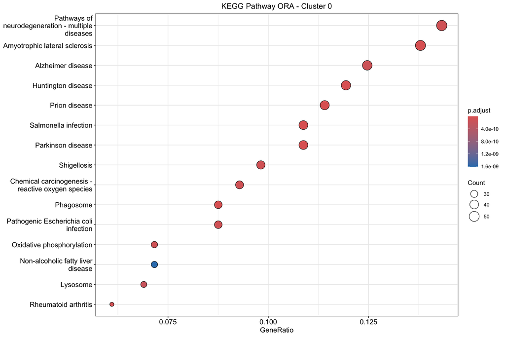

```r
# visualize with dotplot
dotplot(
  kegg_ora_result,
  showCategory = 15
) +
  ggtitle("KEGG Pathway ORA - Cluster 0") +
  theme(
    plot.title = element_text(hjust = 0.5)
  )
```

```r
# save figure
ggsave(
  "../write/figures/kegg_ora_cluster0.png",
  width = 12,
  height = 8
)

# save results table
write_csv(
  x = kegg_ora_result@result,
  file = "../write/tables/kegg_ora_cluster0.csv"
)

# save full results object
write_rds(
  kegg_ora_result,
  "../checkpoints/kegg_ora_cluster0.rds"
)
```

# 4. Gene Set Enrichment Analysis (GSEA)

- GSEA uses the full ranked gene list, not just significant genes
- tests if pathway genes are enriched at extremes of the ranking
- more sensitive than ORA as it uses all gene information
- ranking based on log2FC captures both up and down-regulated pathways

## 4.1 Prepare Ranked Gene List

- create ranked gene list for GSEA
- genes ranked by log2 fold change (positive = upregulated)
- use ALL genes from cluster 0, not just upregulated

```r
# packages
library(tidyverse)
library(magrittr)

# load data
cluster_markers <- read_csv(
  "../write/tables/ifnb_cluster_markers.csv",
  show_col_types = FALSE
)

# get ALL cluster 0 markers (both up and down regulated)
cluster0_all <- cluster_markers %>%
  filter(cluster == 0)

# create ranked gene list (named vector)
ranked_genes <- cluster0_all %>%
  arrange(desc(avg_log2FC)) %>%
  select(
    gene,
    avg_log2FC
  ) %>%
  deframe()

# preview top and bottom of ranked list
head(ranked_genes, 10)
```

```
  C19orf59     CLEC5A       VCAN    CYP27A1       IL1B        OSM CTB-61M7.2
  5.965862   5.544254   5.347446   4.939631   4.675036   4.638795   4.530326
       IL8     S100A8       IER3
  4.519391   4.501904   4.071177
```

```r
tail(ranked_genes, 10)
```

```
    ISG15      CCR7     RSAD2   TNFSF10     IFIT3     IFIT2     IFIT1      CCL8
-4.926955 -4.972063 -4.999327 -5.489534 -5.775539 -5.797930 -6.263104 -6.555438
   CXCL11    CXCL10
-6.710064 -6.859861
```

```r
# show total genes
paste(
  "Total genes in ranked list:",
  length(ranked_genes)
)
```

```
[1] "Total genes in ranked list: 957"
```

```r
# save ranked list
write_rds(
  ranked_genes,
  "../checkpoints/cluster0_ranked_genes.rds"
)
```

## 4.2 GO GSEA (Biological Process)

- GSEA on Gene Ontology Biological Process terms
- identifies pathways enriched in up or down-regulated genes

```r
# packages
library(tidyverse)
library(clusterProfiler)
library(org.Hs.eg.db)
library(enrichplot)
library(magrittr)

# load data
ranked_genes <- read_rds("../checkpoints/cluster0_ranked_genes.rds")

# perform GO GSEA
go_gsea_result <- gseGO(
  geneList = ranked_genes,
  OrgDb = org.Hs.eg.db,
  keyType = "SYMBOL",
  ont = "BP",
  minGSSize = 10,
  maxGSSize = 500,
  pvalueCutoff = 0.05,
  verbose = FALSE,
  eps = 0
)

# preview results
go_gsea_result@result %>%
  head(10) %>%
  select(
    Description,
    NES,
    pvalue,
    p.adjust
  )
```

```
                                               Description       NES
GO:0002181                         cytoplasmic translation -2.842574
GO:0051607                       defense response to virus -2.886592
GO:0009615                               response to virus -2.842091
GO:0019079                        viral genome replication -2.795400
GO:0045071 negative regulation of viral genome replication -2.699814
GO:0045069          regulation of viral genome replication -2.711382
GO:0048525            negative regulation of viral process -2.703827
GO:0140374                antiviral innate immune response -2.412437
GO:1903900                  regulation of viral life cycle -2.559929
GO:0015711                         organic anion transport  2.413449
                 pvalue     p.adjust
GO:0002181 9.646388e-16 1.382327e-12
GO:0051607 3.588697e-14 1.756991e-11
GO:0009615 3.678279e-14 1.756991e-11
GO:0019079 3.592978e-12 1.287184e-09
GO:0045071 2.077842e-11 5.955095e-09
GO:0045069 2.787979e-10 6.658623e-08
GO:0048525 3.411853e-10 6.984550e-08
GO:0140374 2.163628e-09 3.875599e-07
GO:1903900 6.980840e-09 1.111505e-06
GO:0015711 3.665316e-08 5.252398e-06
```

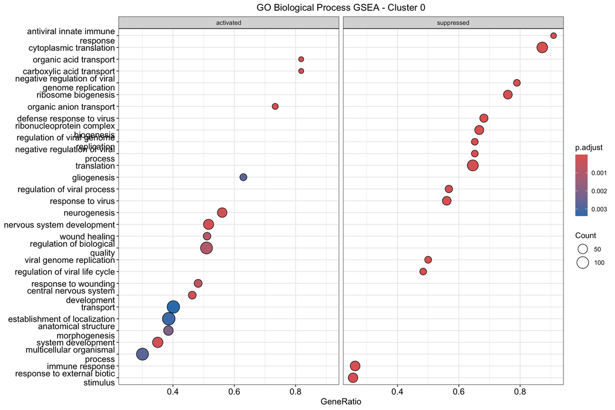

```r
# visualize with dotplot (split by activated/suppressed)
dotplot(
  go_gsea_result,
  showCategory = 15,
  split = ".sign"
) +
  facet_grid(. ~ .sign) +
  ggtitle("GO Biological Process GSEA - Cluster 0") +
  theme(
    plot.title = element_text(hjust = 0.5)
  )
```

```r
# save figure
ggsave(
  "../write/figures/go_gsea_cluster0.png",
  width = 12,
  height = 8
)

# save results table
write_csv(
  x = go_gsea_result@result,
  file = "../write/tables/go_gsea_cluster0.csv"
)

# save full results object
write_rds(
  go_gsea_result,
  "../checkpoints/go_gsea_cluster0.rds"
)
```

## 4.3 Prepare Entrez Ranked List for KEGG

- KEGG requires Entrez IDs rather than gene symbols
- convert gene symbols to Entrez IDs while preserving ranking

```r
# packages
library(tidyverse)
library(clusterProfiler)
library(org.Hs.eg.db)
library(magrittr)

# load data
cluster_markers <- read_csv(
  "../write/tables/ifnb_cluster_markers.csv",
  show_col_types = FALSE
)

# get ALL cluster 0 markers
cluster0_all <- cluster_markers %>%
  filter(cluster == 0)

# convert gene symbols to Entrez IDs
gene_mapping <- bitr(
  cluster0_all$gene,
  fromType = "SYMBOL",
  toType = "ENTREZID",
  OrgDb = org.Hs.eg.db
)

# merge with log2FC values and create ranked list
entrez_ranked <- cluster0_all %>%
  inner_join(
    gene_mapping,
    by = c("gene" = "SYMBOL")
  ) %>%
  arrange(desc(avg_log2FC)) %>%
  select(
    ENTREZID,
    avg_log2FC
  ) %>%
  distinct(
    ENTREZID,
    .keep_all = TRUE
  ) %>%
  deframe()

# preview
head(entrez_ranked, 10)
```

```
   23601     1462     1593     3553     5008     6279     8870     7057
5.544254 5.347446 4.939631 4.675036 4.638795 4.501904 4.071177 3.986682
   55022     2921
3.967935 3.896486
```

```r
# show conversion results
paste(
  "Genes in Entrez ranked list:",
  length(entrez_ranked)
)
```

```
[1] "Genes in Entrez ranked list: 904"
```

```r
# save Entrez ranked list
write_rds(
  entrez_ranked,
  "../checkpoints/cluster0_entrez_ranked.rds"
)
```

## 4.4 KEGG GSEA

- GSEA on KEGG pathways
- uses Entrez ID ranked list prepared in previous chunk

```r
# packages
library(tidyverse)
library(clusterProfiler)
library(enrichplot)
library(magrittr)

# load data
entrez_ranked <- read_rds("../checkpoints/cluster0_entrez_ranked.rds")

# perform KEGG GSEA
kegg_gsea_result <- gseKEGG(
  geneList = entrez_ranked,
  organism = "hsa",
  minGSSize = 10,
  maxGSSize = 500,
  pvalueCutoff = 0.05,
  verbose = FALSE,
  eps = 0
)

# preview results
kegg_gsea_result@result %>%
  head(10) %>%
  select(
    Description,
    NES,
    pvalue,
    p.adjust
  )
```

[output not shown]

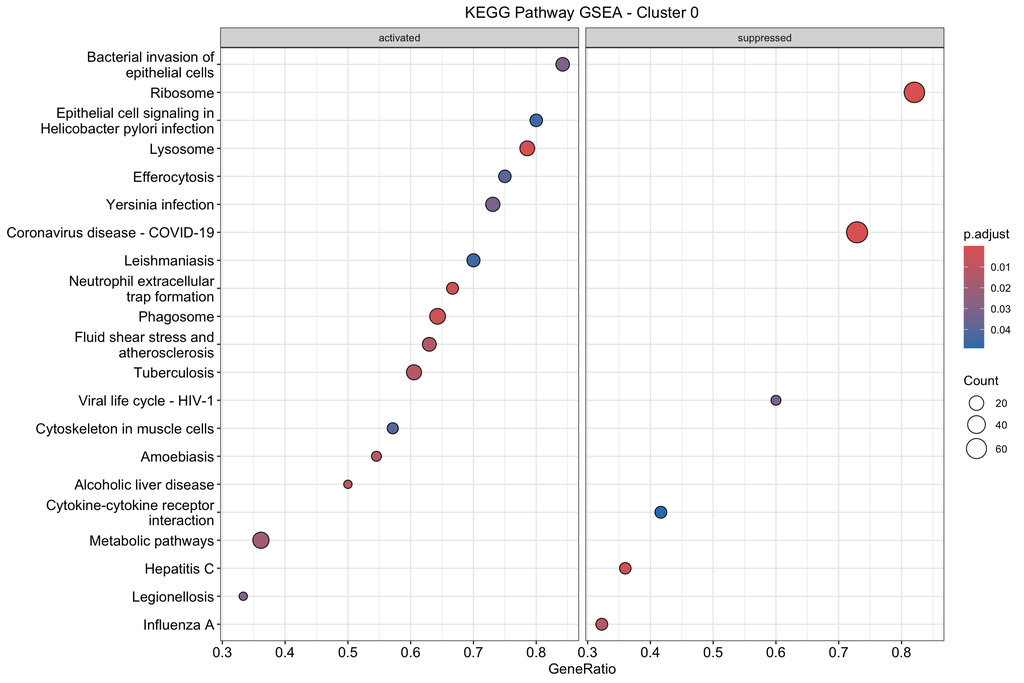

```r
# visualize with dotplot (split by activated/suppressed)
dotplot(
  kegg_gsea_result,
  showCategory = 15,
  split = ".sign"
) +
  facet_grid(. ~ .sign) +
  ggtitle("KEGG Pathway GSEA - Cluster 0") +
  theme(
    plot.title = element_text(hjust = 0.5)
  )
```

```r
# save figure
ggsave(
  "../write/figures/kegg_gsea_cluster0.png",
  width = 12,
  height = 8
)

# save results table
write_csv(
  x = kegg_gsea_result@result,
  file = "../write/tables/kegg_gsea_cluster0.csv"
)

# save full results object
write_rds(
  kegg_gsea_result,
  "../checkpoints/kegg_gsea_cluster0.rds"
)
```

## 4.5 GSEA Enrichment Plot - GO

- enrichment plots show running enrichment score along ranked gene list
- visualize how pathway genes are distributed in the ranking

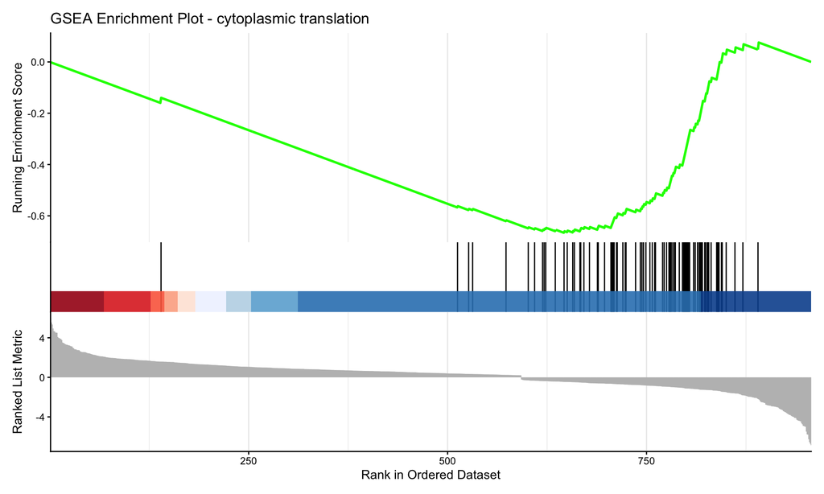

```r
# packages
library(tidyverse)
library(clusterProfiler)
library(enrichplot)
library(magrittr)

# load data
go_gsea_result <- read_rds("../checkpoints/go_gsea_cluster0.rds")

# get top GO term
top_go_term <- go_gsea_result@result$ID[1]
top_go_description <- go_gsea_result@result$Description[1]

# create enrichment plot
gseaplot2(
  go_gsea_result,
  geneSetID = top_go_term,
  title = paste(
    "GSEA Enrichment Plot -",
    top_go_description
  )
)
```

```r
# save figure
ggsave(
  "../write/figures/gsea_enrichment_go_cluster0.png",
  width = 10,
  height = 6
)
```

## 4.6 GSEA Enrichment Plot - KEGG

- enrichment plot for top KEGG pathway
- shows running score and gene distribution

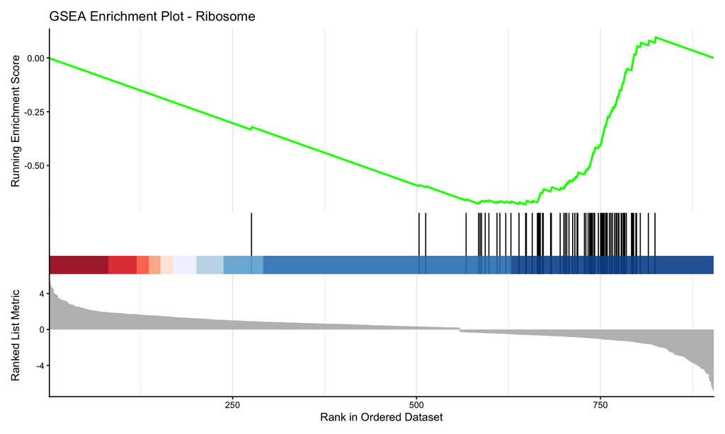

```r
# packages
library(tidyverse)
library(clusterProfiler)
library(enrichplot)
library(magrittr)

# load data
kegg_gsea_result <- read_rds("../checkpoints/kegg_gsea_cluster0.rds")

# get top KEGG term
top_kegg_term <- kegg_gsea_result@result$ID[1]
top_kegg_description <- kegg_gsea_result@result$Description[1]

# create enrichment plot
gseaplot2(
  kegg_gsea_result,
  geneSetID = top_kegg_term,
  title = paste(
    "GSEA Enrichment Plot -",
    top_kegg_description
  )
)
```

```r
# save figure
ggsave(
  "../write/figures/gsea_enrichment_kegg_cluster0.png",
  width = 10,
  height = 6
)
```

# Summary

- we performed differential expression analysis to identify cluster marker genes
- focused on cluster 0 for pathway enrichment analysis
- over-representation analysis (ORA) identified enriched GO terms and KEGG pathways
- gene set enrichment analysis (GSEA) provided a more sensitive pathway analysis
- results saved as CSV files and visualizations for further interpretation
- to analyze other clusters, simply change `cluster == 0` to your cluster of interest

| Analysis | Method | Key Functions |
| --- | --- | --- |
| DEA | Wilcoxon | `FindAllMarkers()`, `DoHeatmap()` |
| GO ORA | Hypergeometric | `enrichGO()`, `dotplot()` |
| KEGG ORA | Hypergeometric | `enrichKEGG()`, `dotplot()` |
| GO GSEA | Kolmogorov-Smirnov | `gseGO()`, `gseaplot2()` |
| KEGG GSEA | Kolmogorov-Smirnov | `gseKEGG()`, `gseaplot2()` |

# Session Information